# TP 2: Principle components regression

OUAZZANI CHAHDI Mohammed

CHERKAOUI Ayoub

KERZAZI Achraf

## Exercise 1: Data

This code allows us to plot the plot the coordinates of each population in our data and superpose it with a map

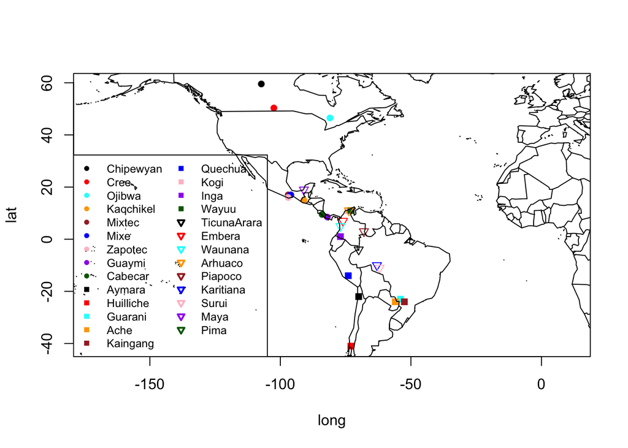

```r
NAm2 = read.table("NAm2.txt", header=TRUE)
names=unique(NAm2$Pop)
npop=length(names)
coord=unique(NAm2[,c("Pop","long","lat")]) #coordinates for each pop
colPalette=rep(c("black","red","cyan","orange","brown","blue","pink",
"purple","darkgreen"),3)
pch=rep(c(16,15,25),each=9)
plot(coord[,c("long","lat")],pch=pch,col=colPalette,asp=1)
# asp allows to have the correct ratio between axis longitude
# and latitude, thus the map is not deformed
legend("bottomleft",legend=names,col=colPalette,lty=-1,
pch=pch,cex=0.75,ncol=2,lwd=2)
library(maps); map("world",add=T)
```

As the data is primarily fetched from the data set provided on “NAm2.txt”, the “unique” command assures the selection of population names in a set from a mathematical sense (no repetition).

Later each population is provided by its coordinates to be plotted subsequently in the world map using the “map” library.

## Exercise 2 :

We build multiple linear regression model to predict the location of each individual using the genetic data. We do this knowing that rank(X) < p(number of samples)

```r
#data containing genetic traits
NAaux = NAm2[,-c(1:8)]
valid <- seq(from = 3, to = nrow(NAaux), by = 3 )
long <- NAm2[-valid,]$long
#bulding model
modelNoPc <- lm(long~., data=NAaux[-valid,])

#predicting with validation set
predictions_validation <- predict(modelNoPc, NAaux[valid, ])
#predicting with training set
predictions_training <- predict(modelNoPc, NAaux[-valid, ])
mean_validation_error_long <- mean((NAaux[valid, ]$long - predictions_validation)^2)

mean_training_error_long <- mean((NAaux[-valid, ]$long - predictions_training)^2)

mean_validation_error_long
```

```
## [1] NaN
```

```r
mean_training_error_long
```

```
## [1] NaN
```

The prediction is made from a rank-deficient fit, which means that the number of features surpasses (by far) the number of data. In this case the sample size that we have doesn’t provide us with enough information about all the features, therefore information about a lot of features remains unknown, hence predicting on data using these unknown features is irrelevant.

## Exercise 3

### (a).

PCA allows us to resume the most important information about features in a smaller dimension. The features conserved are called the principle components, and we obtain them by using singular value decomposition and getting the eigenvectors for the covariance matrix of the initial data.

### (b).

We plot the proportion of variance in the two cases, with and without scaling

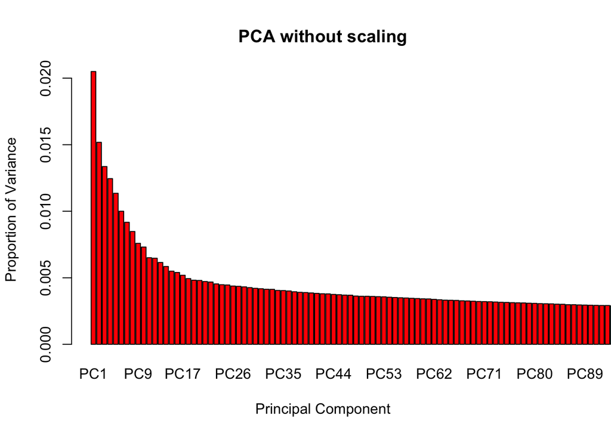

```r
pcaNAm2 <- prcomp(NAaux,center=T, scale=F)
barplot(summary(pcaNAm2)$importance[2,], xlab = "Principal Component", ylab = "Proportion of Variance",  xlim = c(0,100), col="red", main="PCA without scaling")
```

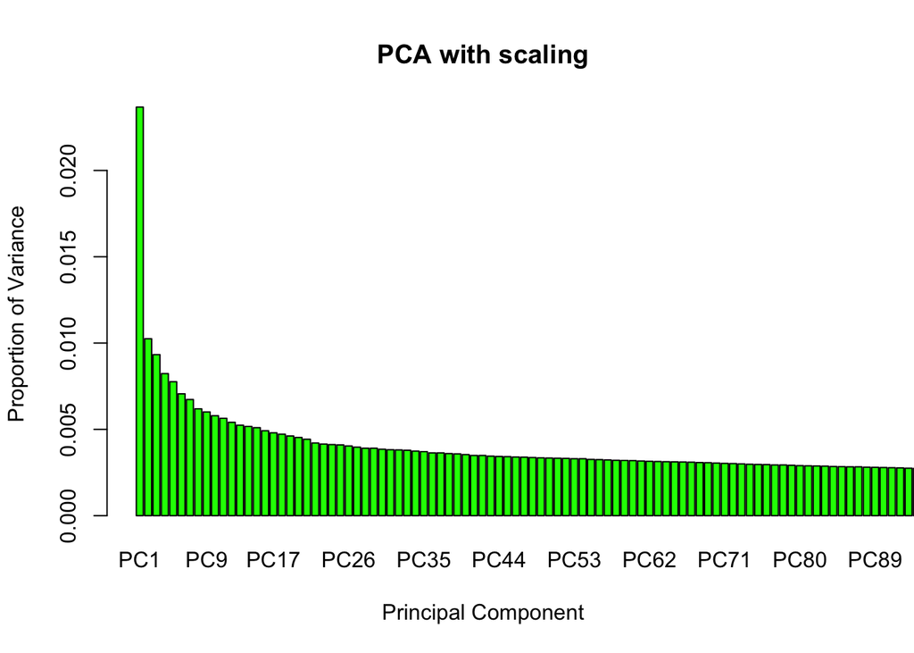

```r
pcaNAm2 <- prcomp(NAaux,center=T, scale=T)
barplot(summary(pcaNAm2)$importance[2,], xlab = "Principal Component", ylab = "Proportion of Variance", xlim = c(0,100), col="green", main="PCA with scaling")
```

// We should use the scale arguments to assure that all the components contribute equally to the PCA.

### (c).

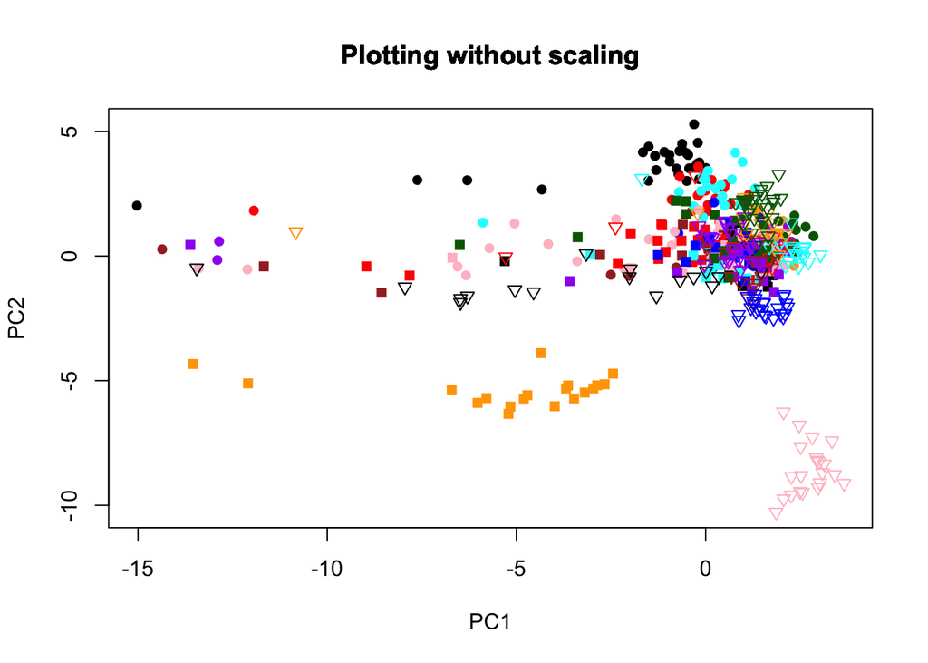

```r
pcaNAm2 <- prcomp(NAaux,center=T, scale=F)
caxes=c(1,2)
plot(pcaNAm2$x[,caxes],col="white")
for (i in 1:npop)
{
lines(pcaNAm2$x[which(NAm2[,3]==names[i]),caxes], type="p",
col=colPalette[i],pch=pch[i])
title(main = "Plotting without scaling")
}
```

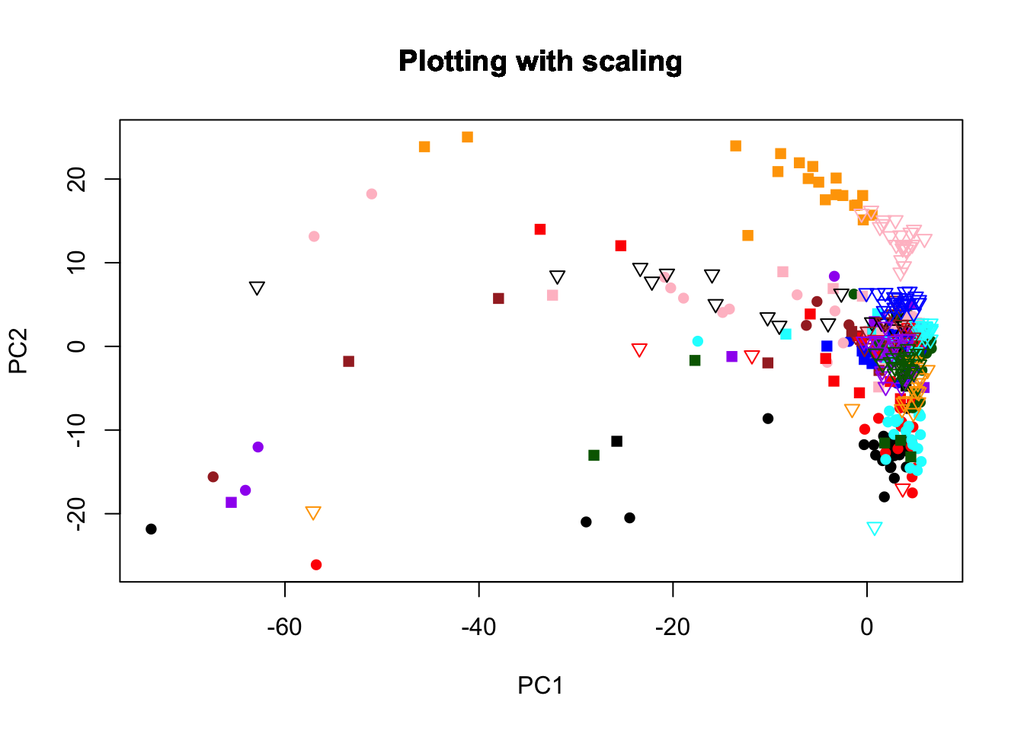

```r
pcaNAm2 <- prcomp(NAaux, center=T, scale=T)
caxes=c(1,2)
plot(pcaNAm2$x[,caxes],col="white")
for (i in 1:npop)
{
lines(pcaNAm2$x[which(NAm2[,3]==names[i]),caxes], type="p",
col=colPalette[i],pch=pch[i])
title(main = "Plotting with scaling")
}
```

### (d).

```r
pcaNAm2 <- prcomp(NAaux,center=T, scale=T)
first_comps_scale = summary(pcaNAm2)$importance[2,1] + summary(pcaNAm2)$importance[2,2]
cat("The variance proportion of the first two Components when scaling : ", first_comps_scale, "\n")
```

```
## The variance proportion of the first two Components when scaling :  0.03392
```

Pour décider le nombre de composantes optimal, on trace la variance cumulée a travers les composantes

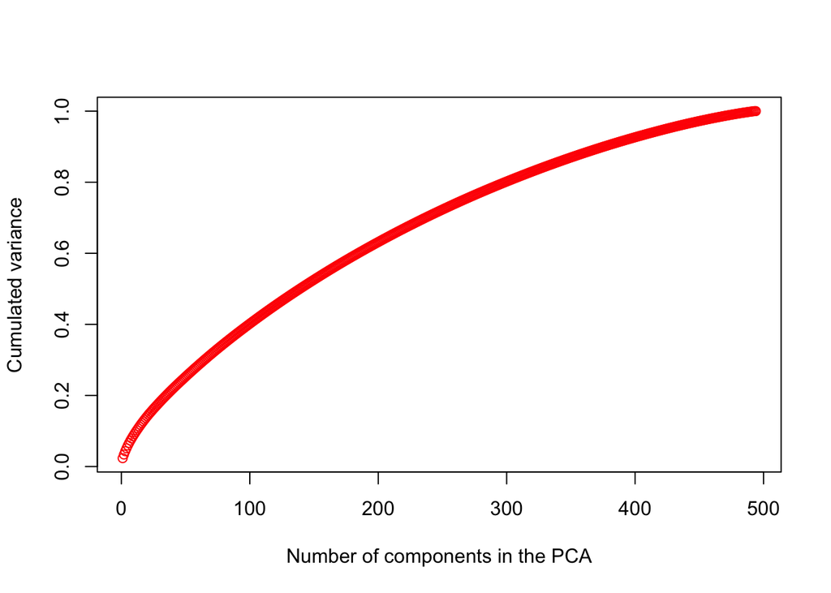

```r
cumulated_variance <- c()
val <- 0
for (i in 1:ncol(summary(pcaNAm2)$importance)){
  val <- val + summary(pcaNAm2)$importance[2,i]
  cumulated_variance <- c(cumulated_variance, val)
}

plot(seq(1 :ncol(summary(pcaNAm2)$importance)), cumulated_variance, xlab = "Number of components in the PCA", ylab = "Cumulated variance", col="red")
```

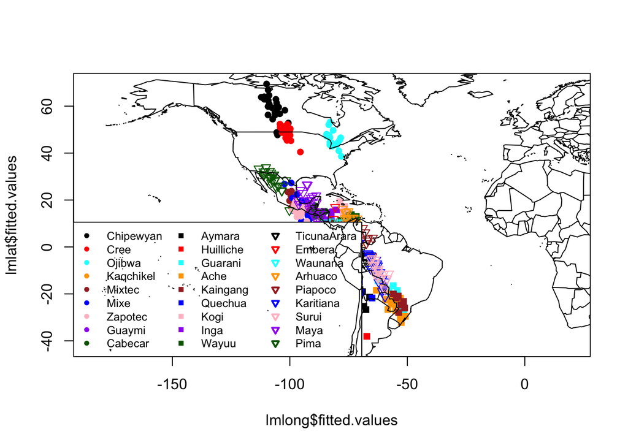

```r
pcrData <- as.data.frame(prcomp(NAaux,center=T, scale=T)$x[,1:250])

long <- NAm2$long
lat <- NAm2$lat

#building model

lmlong <- lm(long~., data=pcrData)
lmlat <- lm(lat~., data=pcrData)

#predicting and plotting
plot(lmlong$fitted.values,lmlat$fitted.values,col="white",asp=1)
for (i in 1:npop)
{
lines(lmlong$fitted.values[which(NAm2[,3]==names[i])],
lmlat$fitted.values[which(NAm2[,3]==names[i])],
type="p", col=colPalette[i],pch=pch[i])
}
legend("bottomleft",legend=names,col=colPalette,lty=-1,
pch=pch, cex=.75,ncol=3,lwd=2)
map("world",add=T)
```

```r
pca_scores <- pcaNAm2$x[,1:250]
lmlat <- lm(NAm2[,7] ~ pca_scores)
lmlong <- lm(NAm2[,8] ~ pca_scores)

plot(lmlong$fitted.values,lmlat$fitted.values,col="white",asp=1)
for (i in 1:npop)
{
    print(names[i])
    lines(lmlong$fitted.values[which(NAm2[,3]==names[i])],
        lmlat$fitted.values[which(NAm2[,3]==names[i])],
        type="p", col=colPalette[i],pch=pch[i])
}
```

```
## [1] "Chipewyan"
## [1] "Cree"
## [1] "Ojibwa"
## [1] "Kaqchikel"
## [1] "Mixtec"
## [1] "Mixe"
## [1] "Zapotec"
## [1] "Guaymi"
## [1] "Cabecar"
## [1] "Aymara"
## [1] "Huilliche"
## [1] "Guarani"
## [1] "Ache"
## [1] "Kaingang"
## [1] "Quechua"
## [1] "Kogi"
## [1] "Inga"
## [1] "Wayuu"
## [1] "TicunaArara"
## [1] "Embera"
## [1] "Waunana"
## [1] "Arhuaco"
## [1] "Piapoco"
## [1] "Karitiana"
## [1] "Surui"
## [1] "Maya"
## [1] "Pima"
```

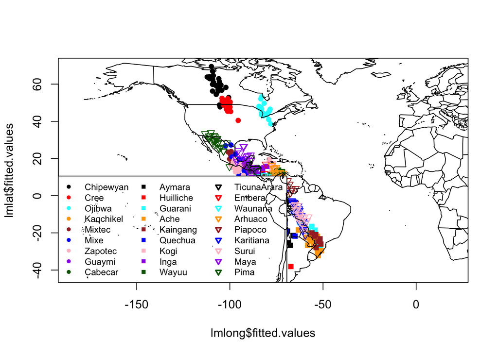

```r
legend("bottomleft",legend=names,col=colPalette,lty=-1,
    pch=pch, cex=.75,ncol=3,lwd=2)
map("world",add=T)
```

The results look similar to the initial map, so the predictions are good. However, we used the whole dataset to train the model, so our model might be too optimistic.

### (b).

We evaluate our model using the real earth distance

```r
library('fields')
predicted_long <- predict(lmlong)
predicted_lat <- predict(lmlat)


real_lat <- NAm2[,7]
real_long <- NAm2[,8]

predicted_coords <- cbind(predicted_long, predicted_lat)
real_coords <- cbind(real_long, real_lat)


dists <- rdist.earth.vec(real_coords, predicted_coords, miles = F)

mean(dists)
```

```
## [1] 476.437
```

## Exercise 5:

### (a)

Cross-validation is a statistical technique that involves partitioning a dataset into subsets, fitting the model on one subset, and evaluating its performance on another subset.

This procedure is very useful when building a predictive model because it helps to estimate the model’s performance on new, unseen data and reduce overfitting. By that we get an accurate estimate of the performance of the model, that generalize better to unseen data. which make it a robust and reliable method.

Creating a vector named vec that contain for each individual the index of the subset to wich he belongs.

```r
#getting the individuals ids
indiv <- NAm2$IndivID

#creating a randomized vector
vec <- c()
for(i in 1:10){
  for(j in 1:49){
    vec <- c(vec, i)
  }
}
vec <- c(vec,round(runif(4, min = 1, max = 10), 0))

vec <- sample(vec)
vec2 <- c(1:494)
```

### (b)

#### 1.

```r
predictedCoord <- data.frame(longitude = vector("numeric", length = 494) , latitude = vector("numeric", length = 494))
```

#### 2.

```r
number_pca <- 4
long <- NAm2$long
lat <- NAm2$lat

indexs_of_training <- vec2[vec != 1]
indexs_of_test <- vec2[vec == 1]


data_train_before_pca <- NAaux[-indexs_of_test,]


PCAs <- prcomp(data_train_before_pca,center=T, scale=F)
pcrData1 <- as.data.frame(PCAs$x[,1:number_pca])
long_train <- long[indexs_of_training ]
vect_long_mean <- rep(mean(long_train), length(long_train))
long_model <- long_train - vect_long_mean

lat_train <- lat[indexs_of_training]
vect_lat_mean <-  rep(mean(lat_train), length(lat_train))
lat_model <- lat_train - vect_lat_mean

#data_train_pca <- pcrData1[indexs_of_trainaing, ]

c_model_long <- lm(long_model~., data = pcrData1 )
c_model_lat <- lm(lat_model~., data = pcrData1 )
```

#### 3.

```r
data_test_without_pca <- NAaux[-indexs_of_training,]
data_test_pca <- as.data.frame( predict(PCAs, data_test_without_pca))

long_model_predicted <- as.numeric(predict(c_model_long, newdata = data_test_pca))
lat_model_predicted <- as.numeric(predict(c_model_lat, newdata = data_test_pca ))



lat_predicted <- lat_model_predicted + rep(mean(lat_train),length(lat_model_predicted ))
long_predicted <- long_model_predicted + rep(mean(long_train),length(long_model_predicted ))

predictedCoord[vec2[vec == i], ] <- cbind(long_predicted, lat_predicted)
```

#### 4.

```r
for(i in 2:10){
  indexs_of_training <- vec2[vec != i]
  indexs_of_test <- vec2[vec == i]


  data_train_before_pca <- NAaux[-indexs_of_test,]

  data_test_without_pca <- NAaux[-indexs_of_training,]

  PCAs <- prcomp(data_train_before_pca,center=T, scale=F)
  pcrData1 <- as.data.frame(PCAs$x[,1:number_pca])
  long_train <- long[indexs_of_training ]
  vect_long_mean <- rep(mean(long_train), length(long_train))
  long_model <- long_train - vect_long_mean

  lat_train <- lat[indexs_of_training]
  vect_lat_mean <-  rep(mean(lat_train), length(lat_train))
  lat_model <- lat_train - vect_lat_mean

  #data_train_pca <- pcrData1[indexs_of_trainaing, ]

  c_model_long <- lm(long_model~., data = pcrData1 )
  c_model_lat <- lm(lat_model~., data = pcrData1 )


  data_test_pca <- as.data.frame( predict(PCAs, data_test_without_pca))

  lat_model_predicted <- as.numeric(predict(c_model_lat, newdata = data_test_pca ))
  lat_predicted <- lat_model_predicted + rep(mean(lat_train),length(lat_model_predicted ))

  long_model_predicted <- as.numeric(predict(c_model_long, newdata = data_test_pca))
  long_predicted <- long_model_predicted + rep(mean(long_train),length(long_model_predicted ))

  predictedCoord[vec2[vec == i], ] <- cbind(long_predicted, lat_predicted)

}


real_coords <- cbind(long, lat)


dists <- rdist.earth.vec(real_coords, predictedCoord, miles = F)

mean(dists)
```

```
## [1] 2613.899
```

### (c)

```r
liste_dists <- c()
liste_dists_train <- c()
long <- NAm2$long
lat <- NAm2$lat
for (number_pca in seq(4, 5, by = 10) ){

      predictedCoord <- data.frame(longitude = vector("numeric", length = 494) , latitude = vector("numeric", length = 494))

      liste_tmp <- c()
      for(i in 1:10){
        indexs_of_training <- vec2[vec != i]
        indexs_of_test <- vec2[vec == i]


        data_train_before_pca <- NAaux[-indexs_of_test,]

        data_test_without_pca <- NAaux[-indexs_of_training,]

        PCAs <- prcomp(data_train_before_pca,center=T, scale=F)
        pcrData1 <- as.data.frame(PCAs$x[,1:number_pca])
        long_train <- long[indexs_of_training ]
        vect_long_mean <- rep(mean(long_train), length(long_train))
        long_model <- long_train - vect_long_mean

        lat_train <- lat[indexs_of_training]
        vect_lat_mean <-  rep(mean(lat_train), length(lat_train))
        lat_model <- lat_train - vect_lat_mean

        #data_train_pca <- pcrData1[indexs_of_trainaing, ]

        c_model_long <- lm(long_model~., data = pcrData1 )
        c_model_lat <- lm(lat_model~., data = pcrData1 )


        data_test_pca <- as.data.frame( predict(PCAs, data_test_without_pca))

        lat_model_predicted <- as.numeric(predict(c_model_lat, newdata = data_test_pca ))
        lat_predicted <- lat_model_predicted + rep(mean(lat_train),length(lat_model_predicted ))

        long_model_predicted <- as.numeric(predict(c_model_long, newdata = data_test_pca))
        long_predicted <- long_model_predicted + rep(mean(long_train),length(long_model_predicted ))

        predictedCoord[vec2[vec == i], ] <- cbind(long_predicted, lat_predicted)





        train_data_train_pca <- as.data.frame( predict(PCAs, data_train_before_pca))

        train_lat_model_predicted <- as.numeric(predict(c_model_lat, newdata = train_data_train_pca ))
        train_lat_predicted <- train_lat_model_predicted + rep(mean(lat_train),length(train_lat_model_predicted ))

        train_long_model_predicted <- as.numeric(predict(c_model_long, newdata = train_data_train_pca))
        train_long_predicted <- train_long_model_predicted + rep(mean(long_train),length(train_long_model_predicted ))

        dists_train <- rdist.earth.vec(data_train_before_pca, cbind(train_long_predicted, train_lat_predicted), miles = F)

        liste_tmp <- c(liste_tmp , mean(dists_train))


      }

      real_coords <- cbind(long, lat)

      dists <- rdist.earth.vec(real_coords, predictedCoord, miles = F)
      liste_dists <- c(liste_dists, mean(dists))

      liste_dists_train <- c(liste_dists_train, mean(liste_tmp))









}
```